# Assignment 6

Ensemble Methods and tuning

I wanted to a) give you the answers (yours may differ slightly because these models use "random" features). Second to show you basically the same process in Python. Many data scientists perfer Python over R. Each does have their advantages and disadvantages.

Like R, Python uses packages in data mining/machine learning. The 3 mose common ones are Pandas (manipulation), Scikit Learn (machine learning) and Matplotlit (graphics).

```python
#Add packages
%matplotlib inline
import numpy as np
import matplotlib.pyplot as plt
import pandas as pd
from sklearn import preprocessing
from sklearn.cross_validation import train_test_split, cross_val_score, KFold
from sklearn.metrics import accuracy_score, precision_score, recall_score, f1_score
from sklearn.metrics import roc_curve, auc, confusion_matrix, classification_report
from sklearn import tree
from sklearn.ensemble import RandomForestClassifier
from sklearn.cross_validation import cross_val_score
import scipy.stats as ss
from sklearn.neighbors import KNeighborsClassifier
from sklearn.grid_search import GridSearchCV
import time
from operator import itemgetter
import os
os.getcwd()
```

```
'/Users/mpgartland1/Documents/Documents/Courses/Data Mining/Week 5'
```

# Read in Data

This is a Pandas operation.

```python
#import data
df = pd.read_csv("bank-full.csv", sep=',')
df.head(10)
```

|  | age::number | job::category | marital::category | education::category | default::category | balance::number | housing::category | loan::category | contact::category | day::number | month::category | duration::number | campaign::number | pdays::number | previous::number | poutcome::category | y::category |
| --- | --- | --- | --- | --- | --- | --- | --- | --- | --- | --- | --- | --- | --- | --- | --- | --- | --- |
| 0 | 58 | management | married | tertiary | no | 2143 | yes | no | unknown | 5 | may | 261 | 1 | -1 | 0 | unknown | no |
| 1 | 44 | technician | single | secondary | no | 29 | yes | no | unknown | 5 | may | 151 | 1 | -1 | 0 | unknown | no |
| 2 | 33 | entrepreneur | married | secondary | no | 2 | yes | yes | unknown | 5 | may | 76 | 1 | -1 | 0 | unknown | no |
| 3 | 47 | blue-collar | married | unknown | no | 1506 | yes | no | unknown | 5 | may | 92 | 1 | -1 | 0 | unknown | no |
| 4 | 33 | unknown | single | unknown | no | 1 | no | no | unknown | 5 | may | 198 | 1 | -1 | 0 | unknown | no |
| 5 | 35 | management | married | tertiary | no | 231 | yes | no | unknown | 5 | may | 139 | 1 | -1 | 0 | unknown | no |
| 6 | 28 | management | single | tertiary | no | 447 | yes | yes | unknown | 5 | may | 217 | 1 | -1 | 0 | unknown | no |
| 7 | 42 | entrepreneur | divorced | tertiary | yes | 2 | yes | no | unknown | 5 | may | 380 | 1 | -1 | 0 | unknown | no |
| 8 | 58 | retired | married | primary | no | 121 | yes | no | unknown | 5 | may | 50 | 1 | -1 | 0 | unknown | no |
| 9 | 43 | technician | single | secondary | no | 593 | yes | no | unknown | 5 | may | 55 | 1 | -1 | 0 | unknown | no |

```python
# See each collum name
print df.columns
```

[output not shown]

# Target

In this step I took the target variable and moved it to the first collum. I aslo made a reference to it called targetName. This just helps me with some below steps.

```python
# designate target variable name
targetName = 'y::category'
# move target variable into first column
targetSeries = df[targetName]
del df[targetName]
df.insert(0, targetName, targetSeries)
expected=targetName
df.head(10)
```

|  | y::category | age::number | job::category | marital::category | education::category | default::category | balance::number | housing::category | loan::category | contact::category | day::number | month::category | duration::number | campaign::number | pdays::number | previous::number | poutcome::category |
| --- | --- | --- | --- | --- | --- | --- | --- | --- | --- | --- | --- | --- | --- | --- | --- | --- | --- |
| 0 | no | 58 | management | married | tertiary | no | 2143 | yes | no | unknown | 5 | may | 261 | 1 | -1 | 0 | unknown |
| 1 | no | 44 | technician | single | secondary | no | 29 | yes | no | unknown | 5 | may | 151 | 1 | -1 | 0 | unknown |
| 2 | no | 33 | entrepreneur | married | secondary | no | 2 | yes | yes | unknown | 5 | may | 76 | 1 | -1 | 0 | unknown |
| 3 | no | 47 | blue-collar | married | unknown | no | 1506 | yes | no | unknown | 5 | may | 92 | 1 | -1 | 0 | unknown |
| 4 | no | 33 | unknown | single | unknown | no | 1 | no | no | unknown | 5 | may | 198 | 1 | -1 | 0 | unknown |
| 5 | no | 35 | management | married | tertiary | no | 231 | yes | no | unknown | 5 | may | 139 | 1 | -1 | 0 | unknown |
| 6 | no | 28 | management | single | tertiary | no | 447 | yes | yes | unknown | 5 | may | 217 | 1 | -1 | 0 | unknown |
| 7 | no | 42 | entrepreneur | divorced | tertiary | yes | 2 | yes | no | unknown | 5 | may | 380 | 1 | -1 | 0 | unknown |
| 8 | no | 58 | retired | married | primary | no | 121 | yes | no | unknown | 5 | may | 50 | 1 | -1 | 0 | unknown |
| 9 | no | 43 | technician | single | secondary | no | 593 | yes | no | unknown | 5 | may | 55 | 1 | -1 | 0 | unknown |

# EDA

Just a touch of EDA. This is the distribution of the target. As you can see, the datset is imbalanced and the target class of interest "yes" is in the minority (a common occurance in classification).

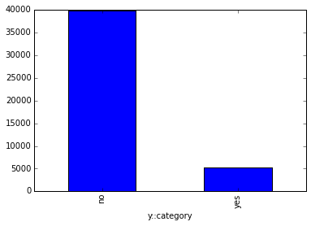

```python
gb = df.groupby(targetName)
targetEDA=gb[targetName].aggregate(len)
plt.figure()
targetEDA.plot(kind='bar', grid=False)
plt.axhline(0, color='k')
```

# Preprocessing

The below two steps are for preprocessing. The first cell changes the yes/no of the target to numeric. I needed to do this as some models require the target to be numeric. The second cell takes all the category features and creates dummies with them. This is stock code I have used for long time (and I did not write it). It is nice because it will take any dataframe of any size and handle categorial features. I do not have to change a single line in it. It can be used generically on bascially any dataframe. Saves a lot of time of coding each feature.

```python
from sklearn import preprocessing
le_dep = preprocessing.LabelEncoder()
#to convert into numbers
df['y::category'] = le_dep.fit_transform(df['y::category'])
```

```python
# perform data transformation
for col in df.columns[1:]:
	attName = col
	dType = df[col].dtype
	missing = pd.isnull(df[col]).any()
	uniqueCount = len(df[attName].value_counts(normalize=False))
	# discretize (create dummies)
	if dType == object:
		df = pd.concat([df, pd.get_dummies(df[col], prefix=col)], axis=1)
		del df[attName]
```

# Test/Train

I split the data into a 70/30 train test. The features are stored in "features_train" and "features_test". The targets are in "target_train" and "target_test".

```python
# split dataset into testing and training
features_train, features_test, target_train, target_test = train_test_split(
    df.ix[:,1:].values, df.ix[:,0].values, test_size=0.30, random_state=0)
```

Just a view of the size of each test/train set.

```python
print features_test.shape
print features_train.shape
print target_test.shape
print target_train.shape
```

```
(13564, 51)
(31647, 51)
(13564,)
(31647,)
```

# Models

All the models are done in Sci-Kit Learn.

# Decision Tree

I created a decision tree from the data. The accurancy of the model was 87%, while the test data classified at 88%. However notice that the "yes" class (the class I am interested in) only properly classified at 46%. That is not great. Again, not uncommon with imbalanced data.

```python
#Decision Tree train model
clf = tree.DecisionTreeClassifier()
clf = clf.fit(features_train, target_train)
#DT test model
target_predicted_dt = clf.predict(features_test)
print "DT Accuracy Score", accuracy_score(target_test, target_predicted_dt)
# print classification report
target_names = ["Fail = no", "Fail = yes"]
print(classification_report(target_test, target_predicted_dt, target_names=target_names))
```

```
DT Accuracy Score 0.873193748157
             precision    recall  f1-score   support

  Fail = no       0.93      0.92      0.93     11969
 Fail = yes       0.46      0.50      0.48      1595

avg / total       0.88      0.87      0.88     13564
```

# Cross Validation of Decision Tree

I cross validated with 10 repeats. You can see the OOB score for each repeat and the mean. The mean is .87, which is quite close to the orginal model. I am not going to worry about over fitting.

```python
#verify DT with Cross Validation
scores = cross_val_score(clf, features_train, target_train, cv=10)
print "Cross Validation Score for each K",scores
scores.mean()
```

```
Cross Validation Score for each K [ 0.86828806  0.87523689  0.87113076  0.87424961  0.86156764  0.87989886
  0.87800253  0.89380531  0.87231353  0.87484197]
```

```
0.87493351576994183
```

# Visual of Confusion Matrix for Decision Tree

```
[[11047   922]
 [  798   797]]
```

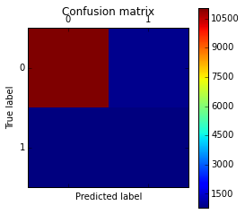

```python
# display confusion matrix
cm = confusion_matrix(target_test, target_predicted_dt)
plt.matshow(cm)
plt.title('Confusion matrix')
plt.colorbar()
plt.ylabel('True label')
plt.xlabel('Predicted label')
print(cm)
```

# Random Forest

Using the same data, I built a random forest with 500 bootstrapped trees. Notice I parallelized this to 4 cores as big random forest can be computationally expensive.

My overall results went up by 2% over the decision tree. Also, my minory target classifcation increased by almost 20%. The minority class of the target is still not great, but better than it was with the Decision tree.

```python
# train random forest model
#paralleized to 4 cores
rf = RandomForestClassifier(n_estimators= 500, n_jobs=4,oob_score=True)
rf.fit(features_train, target_train)
# test random forest model
target_predicted_rf = rf.predict(features_test)
print accuracy_score(target_test, target_predicted_rf)
target_names = ["Fail = no", "Fail = yes"]
print(classification_report(target_test, target_predicted_rf, target_names=target_names))
```

```
0.902462400472
             precision    recall  f1-score   support

  Fail = no       0.92      0.97      0.95     11969
 Fail = yes       0.63      0.40      0.49      1595

avg / total       0.89      0.90      0.89     13564
```

# Cross Validation of Random Forest

I cross validated with 10 repeats. You can see the OOB score for each repeat and the mean. The mean is .90, which is quite close to the orginal model. I am not going to worry about over fitting.

```python
#verify RF with cross validation
scores_rf = cross_val_score(rf, features_train, target_train, cv=10)
print "Cross Validation Score for each K",scores_rf
scores_rf.mean()
```

```
Cross Validation Score for each K [ 0.90397979  0.90366393  0.90397979  0.90521327  0.90233881  0.9073957
  0.90992415  0.91814159  0.90486726  0.90391909]
```

```
0.90634233690677901
```

# Visual of Confusion Matrix for Random Forest

```
[[11599   370]
 [  953   642]]
```

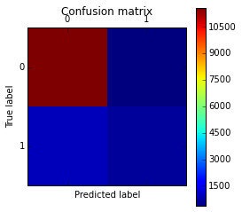

```python
# display confusion matrix
cm = confusion_matrix(target_test, target_predicted_rf)
plt.matshow(cm)
plt.title('Confusion matrix')
plt.colorbar()
plt.ylabel('True label')
plt.xlabel('Predicted label')
print(cm)
```

# Model Tuning

You can tune any argument in these models. I did a grid search only on max_features (mtry in R). I parallelized the job to 4 cores for speed. You can see that max_features (mtry) of 5 had the best results. But frankly was very little difference from the other parameter results.

```python
# use a full grid over all parameters
param_grid = {"max_features": [2, 3, 4, 5]}
start_time = time.clock()




# run grid search
grid_search = GridSearchCV(rf, param_grid=param_grid,n_jobs=4)

grid_search.fit(features_train, target_train)

print time.clock() - start_time, "seconds"
print grid_search.grid_scores_
```

```
29.278299 seconds
[mean: 0.89920, std: 0.00031, params: {'max_features': 2}, mean: 0.90125, std: 0.00103, params: {'max_features': 3}, mean: 0.90233, std: 0.00208, params: {'max_features': 4}, mean: 0.90350, std: 0.00144, params: {'max_features': 5}]
```

# Grid Search NO parallel

I did not ask you to do this, but I wanted to show you the difference in parallel vs serial. Parallel above took 29.2 seconds to run, serial (below) took 177 sec. Same results, just speed. R might be a little slower, to do this. A benefit of Python is it does have better speed.

```python
# use a full grid over all parameters
param_grid = {"max_features": [2, 3, 4, 5]}
start_time = time.clock()

# run grid search
grid_search = GridSearchCV(rf, param_grid=param_grid)

grid_search.fit(features_train, target_train)

print time.clock() - start_time, "seconds"
print grid_search.grid_scores_
```

```
177.914329 seconds
[mean: 0.89920, std: 0.00067, params: {'max_features': 2}, mean: 0.90062, std: 0.00070, params: {'max_features': 3}, mean: 0.90325, std: 0.00104, params: {'max_features': 4}, mean: 0.90381, std: 0.00024, params: {'max_features': 5}]
```

# KNN

I performed KNN on K=3 and K=5. For both K's the accurancy was 87% and I still have problems with the minority class. KNN and Decision Tree perform about the same. I find this to be true frequently, which is why I use them as my base comparative models.

```python
neigh3 = KNeighborsClassifier(n_neighbors=3)
neigh3.fit(features_train, target_train)
# test KNN 3
target_predicted_knn3 = neigh3.predict(features_test)
print accuracy_score(target_test, target_predicted_knn3)
target_names = ["Fail = no", "Fail = yes"]
print(classification_report(target_test, target_predicted_knn3, target_names=target_names))
```

```
0.872014155116
             precision    recall  f1-score   support

  Fail = no       0.91      0.95      0.93     11969
 Fail = yes       0.43      0.29      0.35      1595

avg / total       0.85      0.87      0.86     13564
```

```python
neigh5 = KNeighborsClassifier(n_neighbors=5)
neigh5.fit(features_train, target_train)
# test KNN 3
target_predicted_knn5 = neigh5.predict(features_test)
print accuracy_score(target_test, target_predicted_knn5)
target_names = ["Fail = no", "Fail = yes"]
print(classification_report(target_test, target_predicted_knn5, target_names=target_names))
```

```
0.876142730758
             precision    recall  f1-score   support

  Fail = no       0.91      0.96      0.93     11969
 Fail = yes       0.45      0.26      0.33      1595

avg / total       0.85      0.88      0.86     13564
```

# More Details

```python
#Show importance of each feature in Random Forest
zip(df.columns[1:20], rf.feature_importances_)
```

```
[('age::number', 0.090181124750943073),
 ('balance::number', 0.091815615564434794),
 ('day::number', 0.079477581664978383),
 ('duration::number', 0.26963887558713318),
 ('campaign::number', 0.037783066378533979),
 ('pdays::number', 0.038728300064798347),
 ('previous::number', 0.019575629458679966),
 ('job::category_admin.', 0.0087979362340372472),
 ('job::category_blue-collar', 0.0086132024558311839),
 ('job::category_entrepreneur', 0.0035638373481718128),
 ('job::category_housemaid', 0.0031377257600458839),
 ('job::category_management', 0.010148696421114756),
 ('job::category_retired', 0.0049120624078311378),
 ('job::category_self-employed', 0.0044801711799108265),
 ('job::category_services', 0.0064535791658650752),
 ('job::category_student', 0.0044306602377192084),
 ('job::category_technician', 0.010500291748067849),
 ('job::category_unemployed', 0.0045177462229145232),
 ('job::category_unknown', 0.0013789352750514133)]
```

# ROC curve for Random Forest

Finally a ROC curve that shows the lift I get from the Random Forest model.

```
ROC AUC: 0.927
```

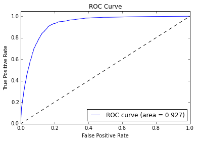

```python
# Determine the false positive and true positive rates
fpr, tpr, _ = roc_curve(target_test, rf.predict_proba(features_test)[:,1])

# Calculate the AUC
roc_auc = auc(fpr, tpr)
print 'ROC AUC: %0.3f' % roc_auc

# Plot of a ROC curve for a specific class
plt.figure()
plt.plot(fpr, tpr, label='ROC curve (area = %0.3f)' % roc_auc)
plt.plot([0, 1], [0, 1], 'k--')
plt.xlim([0.0, 1.0])
plt.ylim([0.0, 1.05])
plt.xlabel('False Positive Rate')
plt.ylabel('True Positive Rate')
plt.title('ROC Curve')
plt.legend(loc="lower right")
plt.show()
```

Random Forest does the best, but I still am not getting the accurancy on my target class of interest. I have a few tricks I can do to work on this, but that is for another day/class.